# 1. Define the Problem

# 5. Developing a model that does better than a baseline

The Naive Bayes Classifier is used as the baseline model for comparison and is trained using the full review training dataset. The test dataset is then used to evaluate the model. Evaluation Metrics such as Accuracy, Precision, and Recall scores are calculated and the model seems to have a 69% accuracy in classifying the movie reviews accurately. An underfit model is first developed using minimum requirements and is fairly simple. Relu is used as the last layer activation function. The RMSprop optimizer is used for this project to train the models since it has a higher convergence speed and can reduce the training time of the models working with large datasets such as our case in this project(What is rmsprop 2022). Since RMSprop has fewer parameters compared to other optimizers it is also easier to tune its hyperparameters.

The Loss and Accuracy values are calculated for each of the models and are visually represented using graphs. The accuracy and loss values are analyzed to ensure that the model is performing as efficiently as possible. Accuracy is used as an evaluation metric during compilation of all the models. However, since the dataset is split into training, testing, and validation, the number of values available in each set is no longer the same, affecting the accuracy measure as accuracy requires all datasets to have the same amount of values. Hence, to ensure the model's highest performance, both the accuracy and loss values are plotted for the underfit, overfit, and regularized models.

```python
# Build the Classifier
NB_model = GaussianNB()

# Train the baseline model
NB_model.fit(x_review_train, y_review_train)

# Predict Output
Output_prediction = NB_model.predict([x_review_test[6]])

#Print the Predicted Output
print("Actual Value of Review:", y_review_test[6])
print("Predicted Value of Review:", Output_prediction[0])
```

```
Actual Value of Review: 1.0
Predicted Value of Review: 1.0
```

```python
#The baseline model is evaluated using the test dataset
y_review_predict = NB_model.predict(x_review_test)
baseline_accu_score = accuracy_score(y_review_test, y_review_predict)
baseline_precision_score = precision_score(y_review_test, y_review_predict, average='weighted')
baseline_recall_score = recall_score(y_review_test, y_review_predict, average=None)

print("Accuracy Score:", baseline_accu_score)
print("Precision Score:", baseline_precision_score)
print("Recall Score:", baseline_recall_score)
```

```
Accuracy Score: 0.69644
Precision Score: 0.7221576989289333
Recall Score: [0.86656 0.52632]
```

```python
#An Underfit model
Review_underfit_model = models.Sequential()
```

```python
#Complie the underfit model
Review_underfit_model.add(layers.Dense(15,activation='relu', input_shape=(10000,)))
Review_underfit_model.compile(optimizer='rmsprop',
              loss='binary_crossentropy',
              metrics=['acc'])

Review_hist = Review_underfit_model.fit(half_x_review_train,
                    half_y_review_train,
                    epochs=10,
                    batch_size=512,
                    validation_data=(x_review_val, y_review_val))
Review_underfit_model.summary()
```

```
Model: "sequential_1"
_________________________________________________________________
 Layer (type)                Output Shape              Param #
=================================================================
 dense_3 (Dense)             (None, 15)                150015

=================================================================
Total params: 150,015
Trainable params: 150,015
Non-trainable params: 0
_________________________________________________________________
```

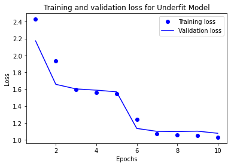

```python
#Plot the Training and Validation loss for Underfit Model
Review_hist_dict = Review_hist.history
underfit_model_loss_values = Review_hist_dict['loss']
underfit_model_val_loss_values = Review_hist_dict['val_loss']

Review_epochs = range(1, len(Review_hist_dict['loss']) + 1)

plt.plot(Review_epochs, underfit_model_loss_values, 'bo', label='Training loss')
plt.plot(Review_epochs, underfit_model_val_loss_values, 'b', label='Validation loss')
plt.title('Training and validation loss for Underfit Model')
plt.xlabel('Epochs')
plt.ylabel('Loss')
plt.legend()

plt.show()
```

[figure not shown]

```python
#Plot the Training and Validation Accuracy for Underfit Model
plt.clf()
underfit_model_accuracy_values = Review_hist_dict['acc']
underfit_model_val_acc_values = Review_hist_dict['val_acc']

Review_epochs = range(1, len(Review_hist_dict['acc']) + 1)

plt.plot(Review_epochs, underfit_model_accuracy_values, 'bo', label='Training acc')
plt.plot(Review_epochs, underfit_model_val_acc_values, 'b', label='Validation acc')
plt.title('Training and validation accuracy of Underfit Model')
plt.xlabel('Epochs')
plt.ylabel('Accuracy')
plt.legend()

plt.show()
```

# 6. Scaling up - developing a model that overfits

```python
#An Overfitting model
Review_overfit_model = models.Sequential()
```

```python
#Complie the Overfitting Model
Review_overfit_model.add(layers.Dense(15, activation='relu', input_shape=(10000,)))
Review_overfit_model.add(layers.Dense(15,activation='relu'))
Review_overfit_model.add(layers.Dense(5,activation='relu'))
Review_overfit_model.compile(optimizer='rmsprop',
              loss='binary_crossentropy',
              metrics=['acc'])

Review__overfit_hist = Review_overfit_model.fit(half_x_review_train,
                    half_y_review_train,
                    epochs=40,
                    batch_size=512,
                    validation_data=(x_review_val, y_review_val))
Review_overfit_model.summary()
```

```
Model: "sequential_3"
_________________________________________________________________
 Layer (type)                Output Shape              Param #
=================================================================
 dense_7 (Dense)             (None, 15)                150015

 dense_8 (Dense)             (None, 15)                240

 dense_9 (Dense)             (None, 5)                 80

=================================================================
Total params: 150,335
Trainable params: 150,335
Non-trainable params: 0
_________________________________________________________________
```

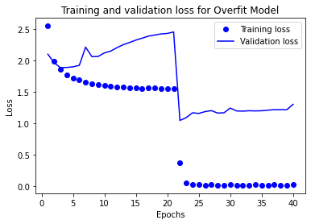

```python
#Plot the Training and Validation loss for Overfit Model
Review_overfit_hist_dict = Review__overfit_hist.history
overfit_model_loss_values = Review_overfit_hist_dict['loss']
overfit_model_val_loss_values = Review_overfit_hist_dict['val_loss']

Review_overfit_epochs = range(1, len(Review_overfit_hist_dict['loss']) + 1)

plt.plot(Review_overfit_epochs, overfit_model_loss_values, 'bo', label='Training loss')
plt.plot(Review_overfit_epochs, overfit_model_val_loss_values, 'b', label='Validation loss')
plt.title('Training and validation loss for Overfit Model')
plt.xlabel('Epochs')
plt.ylabel('Loss')
plt.legend()

plt.show()
```

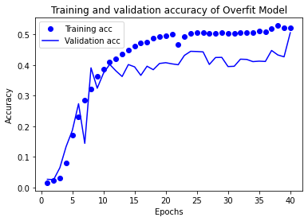

```python
#Plot the Training and Validation Accuracy for Overfit Model
plt.clf()
Overfit_model_accuracy_values = Review_overfit_hist_dict['acc']
Overfit_model_val_accuracy_values = Review_overfit_hist_dict['val_acc']

plt.plot(Review_overfit_epochs, Overfit_model_accuracy_values, 'bo', label='Training acc')
plt.plot(Review_overfit_epochs, Overfit_model_val_accuracy_values, 'b', label='Validation acc')
plt.title('Training and validation accuracy of Overfit Model')
plt.xlabel('Epochs')
plt.ylabel('Accuracy')
plt.legend()

plt.show()
```